# Enterprise R Package Development

4 October 2019

## Outline

A tutorial on how to build packages in R that can be deployed to the Enterprise or to the Comprehensive R Archive Network (CRAN) including continuous integration, testing, and code coverage analysis.

- Quick Introduction to R
- Introduction to R packages
- Open Source Licenses in the Corporate Ecosystem
- Package Development Tech Stack
- Demo
  - https://github.com/bertcarnell/dogfoodcon2019
  - https://github.com/bertcarnell/dogfoodconpackage

## What does the R in Rob stand for?

## A Little About Me

- Diverse Education
  - BS Physics
  - MS Statistics
  - MEM in Engineering Management
  - Nuclear Engineering in US Navy
- Data Science Experience
  - Research - Probabilisitic Risk Assessment, National Security, Bioinformatics, Forensics, Transportation
  - Marketing
  - Banking
- Languages Spoken
  - R, c/C++, python, SAS, Java, C#, javascript, VBA, ASP.NET

## Introduction to R Packages

Packages in R "provide a mechanism for loading optional code, data and documentation as needed. The R distribution itself includes about 30 packages."

CRAN Packages:

- **CRAN** (The Comprehensive R Archive Network): A world-wide mirrored repository of curated extensions (packages) for the R environment.
- **Testing**: CRAN packages are tested on entry and periodically thereafter and are scanned by the CRAN team for use with designated R versions and designated dependent packages.
- **Security**: Code is open source and is usually inspected. Closed source 3rd party binary libraries are discouraged or not allowed. Packages are manually reviewed for a user's first package or if something unusual is requested.

## Introduction to R Pacakges (cont)

Github Packages + other:

- More of the wild west
- Corporate users need to do due dilligence before using a package from github if access is even allowed in the Enterprise
- Most often used as a "faster" way to distribute package bug fixes than the CRAN process
- Also allows package users to see the level of rigor around the package development: continuous integration, testing, code documentation, etc.

## Use Case for Enterprise Package Development

- Great way to standardize, document, and distribute a package
- Can use internal git repository as the package repository
- Much easier for users to re-use validated code
- Automated unit testing and validation against new versions of R and dependent packages
- Fits better within a corporate governance structure as a self-contained tool, rather than a collection of scripts

## Open Source Licenses in the Corporate Ecosystem

Open Source Licenses

- [R](https://www.r-project.org/Licenses/): GNU General Public License (GPL) version 2 or 3
- Most R packages are governed under:
  - MIT
  - GPL, LGPL, AGPL
  - BSD
  - CCBY-4
  - Apache 2.0

Please discuss with your company's legal department about specific policies on these licenses.

Read more at the [Free Software Foundation](https://www.fsf.org/)

## Most Popular CRAN Licenses

From [Here](https://thinkr-open.github.io/licensing-r/intro.html#a-visual-representation-of-the-licenses)

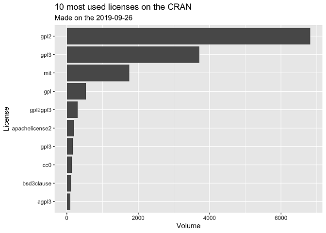

## Package Development Tech Stack

Open Source Tech Stack:

- [R](https://www.r-project.org/)
- Integrated Development Environment: [RStudio](https://rstudio.com/)
- Continuous Integration: [Travis CI](https://travis-ci.org/)
- Test Coverage: [CodeCov](https://codecov.io/)
- Source Control: [git](https://git-scm.com)
- Documentation, Project Management, Collaboration: [github](https://github.com/)

Analogs for each element can be implemented internally in the corporate environment or enterprise licenses can be bought

## Demonstration of Package Environment

## Learn More + R References

The gold standard reference from the R Project:

- [Writing R Extenstions - R](https://cran.r-project.org/doc/manuals/r-release/R-exts.html)

R packages:

- [roxygen2 - Inline R Documentation](https://cran.r-project.org/web/packages/roxygen2/index.html)
- [covr - Test Coverage for Packages](https://cran.r-project.org/web/packages/covr/index.html)
- [devtools - Package development tools](https://cran.r-project.org/web/packages/devtools/index.html)

## Learn More + Getting Started References

Others:

- [STAT 545 - University of British Columbia, Jenny Bryan](http://stat545.com/packages00_index.html)
- [The Political Methodologist](https://thepoliticalmethodologist.com/2014/08/14/building-and-maintaining-r-packages-with-devtools-and-roxygen2/)
- [devtools cheatsheet - RStudio](https://www.rstudio.com/wp-content/uploads/2015/03/devtools-cheatsheet.pdf)
- [Developing R Packages - jtleek](https://github.com/jtleek/rpackages)
- [R Package primer](http://kbroman.org/pkg_primer/)
- [R Packages - Hadley Wickham](http://r-pkgs.had.co.nz/)